# Ask

As part of the marketing analyst team, it is my responsibilty to find how annual members and casual riders use Cyclistic different.

# Prepare

```python
import numpy as np
import pandas as pd
import matplotlib.pyplot as plt
import seaborn as sns

%matplotlib inline
```

```python
#Import data for the past 12 months
jan23 = pd.read_csv(r'C:\Users\omarm\Documents\Repositories\cyclistic_bike_share\202301-divvy-tripdata.csv')
dec22 = pd.read_csv(r'C:\Users\omarm\Documents\Repositories\cyclistic_bike_share\202212-divvy-tripdata.csv')
nov22 = pd.read_csv(r'C:\Users\omarm\Documents\Repositories\cyclistic_bike_share\202211-divvy-tripdata.csv')
oct22 = pd.read_csv(r'C:\Users\omarm\Documents\Repositories\cyclistic_bike_share\202210-divvy-tripdata.csv')
sep22 = pd.read_csv(r'C:\Users\omarm\Documents\Repositories\cyclistic_bike_share\202209-divvy-publictripdata.csv')
aug22 = pd.read_csv(r'C:\Users\omarm\Documents\Repositories\cyclistic_bike_share\202208-divvy-tripdata.csv')
jul22 = pd.read_csv(r'C:\Users\omarm\Documents\Repositories\cyclistic_bike_share\202207-divvy-tripdata.csv')
jun22 = pd.read_csv(r'C:\Users\omarm\Documents\Repositories\cyclistic_bike_share\202206-divvy-tripdata.csv')
may22 = pd.read_csv(r'C:\Users\omarm\Documents\Repositories\cyclistic_bike_share\202205-divvy-tripdata.csv')
apr22 = pd.read_csv(r'C:\Users\omarm\Documents\Repositories\cyclistic_bike_share\202204-divvy-tripdata.csv')
mar22 = pd.read_csv(r'C:\Users\omarm\Documents\Repositories\cyclistic_bike_share\202203-divvy-tripdata.csv')
feb22 = pd.read_csv(r'C:\Users\omarm\Documents\Repositories\cyclistic_bike_share\202202-divvy-tripdata.csv')
```

# Process

```python
#Join the 12 data frames
frames = [jan23, dec22, nov22, oct22, sep22, aug22, jul22, jun22, may22, apr22, mar22, feb22]
past_year = pd.concat(frames)
#Total number of columns, rows
print(past_year.shape)
#Get column names
past_year.columns.values
```

```
(5754248, 13)
```

```
array(['ride_id', 'rideable_type', 'started_at', 'ended_at',
       'start_station_name', 'start_station_id', 'end_station_name',
       'end_station_id', 'start_lat', 'start_lng', 'end_lat', 'end_lng',
       'member_casual'], dtype=object)
```

```python
#Verifying total entries from each month equals entries in 'past_year'(5754248)
entries_month = []
for df in range(len(frames)):
    entries_month.append(frames[df].shape[0])
sum(entries_month)
```

```
5754248
```

```python
# First 5 rows
past_year.head()
```

|  | ride_id | rideable_type | started_at | ended_at | start_station_name | start_station_id | end_station_name | end_station_id | start_lat | start_lng | end_lat | end_lng | member_casual |
| --- | --- | --- | --- | --- | --- | --- | --- | --- | --- | --- | --- | --- | --- |
| 0 | F96D5A74A3E41399 | electric_bike | 2023-01-21 20:05:42 | 2023-01-21 20:16:33 | Lincoln Ave & Fullerton Ave | TA1309000058 | Hampden Ct & Diversey Ave | 202480.0 | 41.924074 | -87.646278 | 41.930000 | -87.640000 | member |
| 1 | 13CB7EB698CEDB88 | classic_bike | 2023-01-10 15:37:36 | 2023-01-10 15:46:05 | Kimbark Ave & 53rd St | TA1309000037 | Greenwood Ave & 47th St | TA1308000002 | 41.799568 | -87.594747 | 41.809835 | -87.599383 | member |
| 2 | BD88A2E670661CE5 | electric_bike | 2023-01-02 07:51:57 | 2023-01-02 08:05:11 | Western Ave & Lunt Ave | RP-005 | Valli Produce - Evanston Plaza | 599 | 42.008571 | -87.690483 | 42.039742 | -87.699413 | casual |
| 3 | C90792D034FED968 | classic_bike | 2023-01-22 10:52:58 | 2023-01-22 11:01:44 | Kimbark Ave & 53rd St | TA1309000037 | Greenwood Ave & 47th St | TA1308000002 | 41.799568 | -87.594747 | 41.809835 | -87.599383 | member |
| 4 | 3397017529188E8A | classic_bike | 2023-01-12 13:58:01 | 2023-01-12 14:13:20 | Kimbark Ave & 53rd St | TA1309000037 | Greenwood Ave & 47th St | TA1308000002 | 41.799568 | -87.594747 | 41.809835 | -87.599383 | member |

## Drop columns we will not be using

```python
past_year = past_year.drop(['start_lat','start_lng','end_lat','end_lng'], axis=1)
```

## Convert to appropriate data type

```python
# Check initial data types
past_year.dtypes
```

```
ride_id               object
rideable_type         object
started_at            object
ended_at              object
start_station_name    object
start_station_id      object
end_station_name      object
end_station_id        object
member_casual         object
dtype: object
```

```python
date_type = ['started_at', 'ended_at']
past_year[date_type] = past_year[date_type].apply(pd.to_datetime)
past_year.dtypes
```

```
ride_id                       object
rideable_type                 object
started_at            datetime64[ns]
ended_at              datetime64[ns]
start_station_name            object
start_station_id              object
end_station_name              object
end_station_id                object
member_casual                 object
dtype: object
```

## Drop duplicate entries

```python
drop_dupes = past_year.drop_duplicates(subset=['ride_id'])
print('Dropped', past_year.shape[0] - drop_dupes.shape[0],'duplicates.')
#Assign dataframe with no duplicates to 'past_year'
past_year = drop_dupes
```

```
Dropped 0 duplicates.
```

## Drop missing values

```python
drop_na = past_year.dropna()
print('Dropped', past_year.shape[0] - drop_na.shape[0], 'entries that had missing values.')
#Assign dataframe with no missing values to 'past_year'
past_year = drop_na
```

```
Dropped 1316732 entries that had missing values.
```

## Drop observations with invalid ride lengths

Create column **'ride_length'** measuring length of bike trips in **minutes**

```python
past_year = past_year.copy()
past_year['ride_length'] = ((past_year['ended_at'] - past_year['started_at']) / pd.Timedelta(minutes=1)).round(3)
past_year['ride_length'].sort_values()
```

```
154251     -168.700
301277     -129.083
126532     -127.017
174725      -57.983
246644      -57.033
            ...
11958     10807.217
38517     10905.967
145568    13928.217
717461    32035.450
67464     34354.067
Name: ride_length, Length: 4437516, dtype: float64
```

```python
# Filter out observations with invalid times
# Invalid times includes trips shorter than 0 hours or longer than 24 hours
past_year_filtered = past_year[(past_year['ride_length'] > 0 ) & (past_year['ride_length'] <=1440)]
print('Dropped', past_year.shape[0]-past_year_filtered.shape[0], 'observations with invalid length times.')
past_year = past_year_filtered
```

```
Dropped 456 observations with invalid length times.
```

## Deal with outliers

```python
# Find outliers using IQR method
q1 = past_year['ride_length'].quantile(.25)
median = past_year['ride_length'].median()
q3 = past_year['ride_length'].quantile(.75)
IQR = q3-q1
upper_fence = q3 + (1.5*IQR)
lower_fence = q1 - (1.5*IQR)
outliers = past_year.loc[(past_year['ride_length']<lower_fence) | (past_year['ride_length']>upper_fence)]
print(np.round(outliers.shape[0]/past_year.shape[0]*100,3),'% of the total data are outliers.')
```

```
7.539 % of the total data are outliers.
```

```python
# Remove outliers
past_year = past_year[(past_year['ride_length'] >lower_fence) & (past_year['ride_length'] <upper_fence)]
outliers = past_year.loc[(past_year['ride_length']<lower_fence) | (past_year['ride_length']>upper_fence)]
print(np.round(outliers.shape[0]/past_year.shape[0]*100,3),'% of the total data are outliers.')
```

```
0.0 % of the total data are outliers.
```

## Create a colum, 'day_of_week', calculating the starting day of each trip

```python
day_of_week = past_year['started_at'].dt.day_name()
past_year = past_year.assign(day_of_week=day_of_week)
past_year['day_of_week']
```

```
0         Saturday
1          Tuesday
2           Monday
3           Sunday
4         Thursday
            ...
114851      Monday
115227      Friday
115228      Friday
115601    Saturday
115606      Monday
Name: day_of_week, Length: 4102554, dtype: object
```

## Create a colum, 'starting_hour', calculating the starting hour of each trip

```python
starting_hour = past_year['started_at'].dt.hour
past_year = past_year.assign(starting_hour=starting_hour)
past_year['starting_hour']
```

```
0         20
1         15
2          7
3         10
4         13
          ..
114851    17
115227     9
115228     9
115601    23
115606     9
Name: starting_hour, Length: 4102554, dtype: int64
```

## Create a colum, 'month', calculating the month of each trip

```python
month = past_year['started_at'].dt.month_name()
past_year = past_year.assign(month=month)
past_year['month']
```

```
0          January
1          January
2          January
3          January
4          January
            ...
114851    February
115227    February
115228    February
115601    February
115606    February
Name: month, Length: 4102554, dtype: object
```

# Analyze

## Descriptive Analysis

```python
# Mean, median, minumum, and maximum for ride length
past_year['ride_length'].agg(['mean','min','median','max'])
```

```
mean      11.960101
min        0.017000
median     9.733000
max       38.200000
Name: ride_length, dtype: float64
```

```python
# Comparing the mean, median, minumum, and maximum
# ride length between members and casual riders.
past_year.groupby('member_casual')['ride_length'].agg(['mean','min','median','max'])
```

| member_casual | mean | min | median | max |
| --- | --- | --- | --- | --- |
| casual | 13.863478 | 0.017 | 11.783 | 38.2 |
| member | 10.840556 | 0.017 | 8.667 | 38.2 |

```python
# Comparing the mean ride length for members and casual riders
# for each day of the week.
day_member = past_year.groupby(['day_of_week','member_casual'])['ride_length'].agg(['mean']).sort_values(by='day_of_week')
# Reorder days from Monday-Sunday
day_member = day_member.loc[['Monday', 'Tuesday','Wednesday','Thursday','Friday','Saturday','Sunday']]
day_member
```

| day_of_week | member_casual | mean |
| --- | --- | --- |
| Monday | casual | 13.688929 |
|  | member | 10.526468 |
| Tuesday | casual | 12.877990 |
|  | member | 10.471070 |
| Wednesday | casual | 12.877672 |
|  | member | 10.570522 |
| Thursday | casual | 13.058479 |
|  | member | 10.641465 |
| Friday | casual | 13.601802 |
|  | member | 10.669286 |
| Saturday | casual | 14.984771 |
|  | member | 11.765116 |
| Sunday | casual | 14.937968 |
|  | member | 11.609023 |

```python
# Analyze ridership data by type and weekday
count_mean = past_year.groupby(['day_of_week','member_casual']).agg({'member_casual':'size','ride_length':'mean'})
count_mean = count_mean.loc[['Monday', 'Tuesday','Wednesday','Thursday','Friday','Saturday','Sunday']]
count_mean
```

| day_of_week | member_casual | member_casual | ride_length |
| --- | --- | --- | --- |
| Monday | casual | 180269 | 13.688929 |
|  | member | 372255 | 10.526468 |
| Tuesday | casual | 176564 | 12.877990 |
|  | member | 414319 | 10.471070 |
| Wednesday | casual | 184040 | 12.877672 |
|  | member | 412198 | 10.570522 |
| Thursday | casual | 205265 | 13.058479 |
|  | member | 411853 | 10.641465 |
| Friday | casual | 219248 | 13.601802 |
|  | member | 356501 | 10.669286 |
| Saturday | casual | 304132 | 14.984771 |
|  | member | 326480 | 11.765116 |
| Sunday | casual | 249871 | 14.937968 |
|  | member | 289559 | 11.609023 |

```python
# Find the hour that is most common for a trip to start for each membership type
past_year.groupby('member_casual')['starting_hour'].agg([pd.Series.mode])
```

| member_casual | mode |
| --- | --- |
| casual | 17 |
| member | 17 |

```python
# Find the mean starting hour for each membership type
past_year.groupby('member_casual')['starting_hour'].agg(['mean'])
```

| member_casual | mean |
| --- | --- |
| casual | 14.610178 |
| member | 13.938767 |

```python
# Find te most popular month to ride in for each membership type
past_year.groupby('member_casual')['month'].agg([pd.Series.mode])
```

| member_casual | mode |
| --- | --- |
| casual | July |
| member | August |

# Share

### Number of rides per membership type

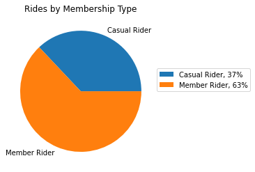

```python
data = past_year.groupby('member_casual')['member_casual'].count()
types = ['Casual Rider','Member Rider']
percents = [x for x in data/data.sum()*100]
labels = [f'{l}, {s:0.0f}%' for l,s in zip(types, percents)]

plt.pie(data, labels=types)
plt.legend(loc=(1,.5), labels = labels)
plt.title('Rides by Membership Type')
plt.show()
```

With a pie chart we can see that members make up a majority of all riders in the last year.

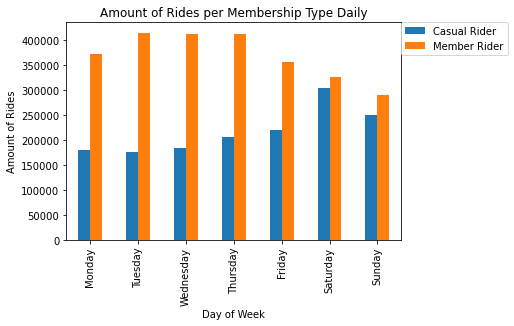

```python
order = ['Monday', 'Tuesday','Wednesday','Thursday','Friday','Saturday','Sunday']
count = past_year.groupby(['day_of_week','member_casual'])['member_casual'].count()
count.unstack().loc[order].plot(kind='bar')
plt.title('Amount of Rides per Membership Type Daily')
plt.xlabel('Day of Week')
plt.ylabel('Amount of Rides')
plt.legend(loc=(1,.85),labels=['Casual Rider','Member Rider'])
```

### Average duration per membership type

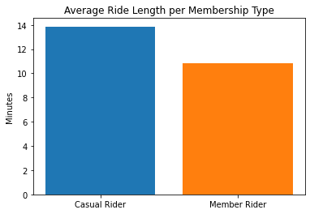

```python
# Get mean ride length per membership
data = past_year.groupby('member_casual').mean()

# Assign x and y values for bar chart
x = ['Casual Rider', 'Member Rider']
y = [data.loc['casual','ride_length'],data.loc['member','ride_length']]

# Create bar chart
plt.bar(x,y,color=('#1f77b4','#ff7f0e'))
plt.title('Average Ride Length per Membership Type')
plt.ylabel('Minutes')
plt.show()
```

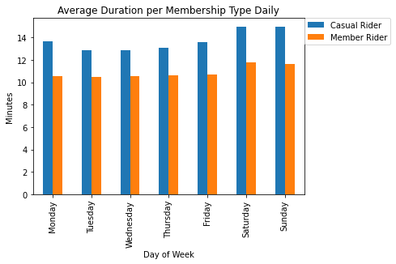

```python
day_member.unstack().loc[order].plot(kind='bar')
plt.title('Average Duration per Membership Type Daily')
plt.xlabel('Day of Week')
plt.ylabel('Minutes')
plt.legend(loc=(1,.85),labels=['Casual Rider','Member Rider'])
```

Overall, casual riders tend to rent out a bike for a longer period of time than riders who have a membership.

Although we knew riders with memberships rent out more bikes, with this chart we are able to see that on the weekends the number of casual riders increases while the number of member riders decreases.

## [Tableau Dashboard](https://public.tableau.com/views/Cyclistic_16855920349170/Dashboard1?:language=en-US&:display_count=n&:origin=viz_share_link)

[figure not shown]

# Act

The majority of Cyclistic's customers already have annual memberships, making up more than 60% of all rides for the past 12 months. However, when we analyze number of rides on a daily basis, we can see that the gap between riders who are members vs non-members is much smaller on weekends. This is due to an increase of rides by non-members and a decrease by members.

Another thing to note is that casual riders tend to ride for longer periods of time both overall and on a daily basis.

# Export dataframe

```python
past_year.to_csv('cyclistic_past_year.csv')
```